# Logistic Regression

Hello, it’s great to be with you again. When we learned about linear regression, we started thinking about different kinds of questions that regression analysis can help us answer. For example, we could consider the factors that contribute to penguins body mass or factors that affect click-throughs on a website. We’re going to expand the kinds of questions we can ask. This time we’ll focus on modeling **the probability that an event will occur**. There are lots of problems that we could explore. For example, what factors influence the odds that a customer buys from a company again? What impacts the likelihood a worker receives high performance ratings? What contributes to a user commenting or not commenting on a video. Logistic regression can help us in these situations.

Logistic regression is a technique that models a categorical dependent variable $Y$ based on one or more independent variables $X$. The dependent variable can have two or more possible discrete values.

We’ll focus mostly on binomial logistic regression, which models the probability of an observation falling into one of two categories based on one or more independent variables. We use a binary variable $Y$ to indicate the category.

For example, let’s say that you’re a data professional working for a basketball team, and you want to understand the probability that any given player on your team will score more than 10 points in the game. There are many variables you might want to consider. For example, how well did the player perform last season? What’s their average playing time? How many points did they score this season? This might seem like a multiple linear regression problem, but consider the outcome variable, whether or not the player will score more than 10 points in a basketball game. This is a binary outcome variable. Since there are only two possible outcomes, we can’t draw a best fit line in the same way we did for linear regression.

For example, if you plot playing times against whether or not the player will score more than 10 points in a game, your data will look like two flat lines, one at $Y = 0$, and one at $Y = 1$.

[figure not shown]

This is very different from the linear relationship you observed in prior scenarios. Later in the program, we’ll learn more about binomial logistic regression and review the stages of regression and pace. We’ll analyze our data by understanding the model assumptions to the best of our ability and ensure we have a binary outcome variable. We’ll construct our model and evaluate it using several different metrics. Then we’ll execute and share the results with stakeholders and other team members.

Logistic regression is a versatile and powerful model and I’m excited to review it with you. So let’s get started

I still remember being on a sports team needing to determine which team first played offense or defense using a coin toss. What’s the chance the coin will come up heads? What’s the chance the coin will come up tails? The probability of either event occurring is 0.5 or 50 percent. This is a classic probability problem. But in the field of data analytics, we get to use a technique called logistic regression to model much more complex probability problems. For example, what factors lead to someone subscribing or not subscribing to a newsletter. Under what circumstances does someone comment on an online video or social media post? Given certain factors, how likely is it that someone renews their membership to an organization?

All of these questions are tackling discrete events or *categorical data*. There are a specific set of possible outcomes. Subscribe or don’t subscribe, comment, or don’t comment, renew, or don’t renew. To answer these questions, data professionals use a model called logistic regression.

Logistic regression is a technique that models a categorical variable based on one or more independent variables. **The dependent variable can have two or more possible discrete values**.

Let’s say that your company has a newsletter and is interested in increasing readership. On the company website users have the opportunity to subscribe to the newsletter. One factor related to the newsletter subscription could be how many minutes the user spends on the web-page before leaving? Our dependent variable $y$ has two possibilities:

- Users don’t subscribe, which we’ll represent with a zero.
- Or users do subscribe, which we’ll represent with a one.

Our independent variable $x$ is continuous and measures how many minutes the users spend on the web-page before leaving.

Let’s graph the hypothetical data on a scatter plot like we would when doing EDA or exploratory data analysis.

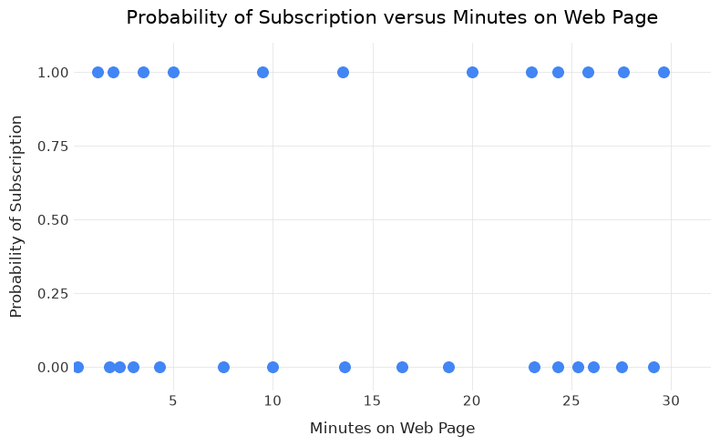

```python
import matplotlib.pyplot as plt
import numpy as np

# Set figure size and resolution
fig, ax = plt.subplots(figsize=(8, 5), dpi=100)

# Sample data points corresponding to the binary response layout
# y = 1.00 data points (Subscribed)
x_ones = [1.2, 2.0, 3.5, 5.0, 9.5, 13.5, 20.0, 23.0, 24.3, 25.8, 27.6, 29.6]
y_ones = [1.00] * len(x_ones)

# y = 0.00 data points (Did not subscribe)
x_zeros = [0.2, 1.8, 2.3, 3.0, 4.3, 7.5, 10.0, 13.6, 16.5, 18.8, 23.1, 24.3, 25.3, 26.1, 27.5, 29.1]
y_zeros = [0.00] * len(x_zeros)

# Plot scatter points (bright blue, matching slide styling)
ax.scatter(x_ones, y_ones, color='#4285f4', s=70, zorder=3)
ax.scatter(x_zeros, y_zeros, color='#4285f4', s=70, zorder=3)

# Set Title and Labels
ax.set_title("Probability of Subscription versus Minutes on Web Page", fontsize=15, pad=15, color='#000000')
ax.set_xlabel("Minutes on Web Page", fontsize=12, labelpad=10, color='#222222')
ax.set_ylabel("Probability of Subscription", fontsize=12, labelpad=10, color='#222222')

# Set Axis Limits and Ticks
ax.set_xlim(0, 32)
ax.set_ylim(-0.08, 1.10)

ax.set_xticks([5, 10, 15, 20, 25, 30])
ax.set_yticks([0.00, 0.25, 0.50, 0.75, 1.00])

# Format y-axis labels to match double-decimal format (0.00, 0.25, etc.)
ax.yaxis.set_major_formatter('{x:.2f}')

# Lightweight grid and spine formatting
ax.grid(True, linestyle='-', linewidth=0.5, color='#e0e0e0', zorder=1)

# Hide frame spines except bottom and left for a clean look
for spine in ['top', 'right', 'left', 'bottom']:
    ax.spines[spine].set_visible(False)

# Remove tick marks for minimal aesthetic
ax.tick_params(axis='both', which='both', length=0, labelsize=11, labelcolor='#333333')

plt.tight_layout()
plt.show()
```

We can observe that the data points are roughly and two horizontal lines.The higher one indicates the user subscribed, this is when $y$ equals one. The lower one indicates that the user did not subscribe. This is when $y$ equals zero, the $x$-axis indicates how long the user was on the site in minutes.

Since the relationship between $x$ and y is not just a straight line, we need a new mathematical way of expressing the relationship between $x$ and $y$. Logistic regression will allow us to model the probability a user will subscribe to the newsletter.

The key concept is that the mean of $y$ given $x$ is equal to the probability of $y$ equals one given $x$.
$$\mu{Y|X} = Prob(Y=1|X) =p$$

Let’s explore this idea. At this point, our observed $y$ values are just a bunch of zeros and ones. To find the mean, we would sum all of our observations and then divide the total by the number of observations. Because some of the observed data are zeros when summing the observations, the zeros all add up to zero. Therefore, the sum of all the observations is equal to the total number of ones. Then we divide by the total number of observations. This is equal to the probability of $y$ equaling one or someone becoming a subscriber.

In this case, we know that the mean of $y$ given $x$ is equal to the probability of $y$ equaling a certain outcome given $x$. Sometimes the probability of $y$ given $x$ is written as $p$ to reinforce the idea of probability. To help you remember, you can think $p$ is for probability. Now we want to understand what variables help explain those probabilities.

Mathematically, we need a way to relate the $x$ variables to the probability that $y$ equals one. Imagine we only have one independent variable.

So then we need to relate the probability of $y =1$ to $\beta_0 + \beta_1 \times x$.
$${\beta_0} + {\beta_1} X \to \text{???} \to Prob(Y=1|X)$$

In logistic regression, we use a link function to express the relationship between the $x$’s and the probability that $y$ equals some outcome.
$${\beta_0} + {\beta_1} X \to \text{???} \to Prob(Y=1|X)$$

$$\text{link function} \to g(p) = {\beta_0} + {\beta_1} X$$

A link function is a non-linear function that connects or links the dependent variable to the independent variables mathematically. We will discuss how logistic regression and link functions work in more detail later on. But for now, just know that this is an example of the differences between linear and logistic regression models.

Let’s review a few more similarities and differences between modeling approaches.

- First, linear regression involves a $y$ that is continuous, like book sales. While logistic regression involves a $y$ that is categorical, like newsletter subscription. Choosing one model over the other is about the kind of data you have.
- You can answer similar questions about what factors impact an outcome of interests.
- Secondly, since linear regression model is a continuous variable, we’re estimating the mean of $y$. But logistic regression models a categorical variable. We’re modeling the probability of an outcome, For example, if $y$ equals one or if $y$ equals zero.
- Lastly, for linear regression, we can express $y$ directly as a function of $x$. But for logistic regression, we need a link function to connect the probability of $y$ with $x$.

We’ll continue focusing on logistic regression with just two categories, like the subscription problem. But there are more complex versions of logistic regression that can model multiple outcomes or categories, such as types of skincare products people buy, or types of services that people receive.

In this video, we covered the basics of logistic regression. We also compared and contrasted linear and logistic regression models.

Later in this course we’ll cover an estimation technique for logistic regression called *maximum likelihood estimation* and we’ll uncover a bit more of the math. For now, know that computers are incredibly powerful and enable us as data practitioners to focus less on the math and more on the storytelling.

The rest of the course will provide you with a solid understanding so you know what’s going on in that powerful machine of yours.

# 1 Find the best logistic regression model for your data

So far, we’ve learned that binomial logistic regression is a method for modeling the probability of a binary outcome, such as, how likely it is that a player will score more than 10 points in a basketball game. Will a user comment or not? But just like any other statistical method, we have to make assumptions about the data to have confidence in the results. Now we’ll discuss the main assumptions of binomial logistic regression and consider how to find the best logistic regression model, given a set of data. Logistic regression is a bit more complex than linear regression. So our goal is to understand the basics of how it works, not to understand every detail of the model.

Recall that as we navigate the first two stages of pace, we can figure out if a logistic regression model is the best choice to address the question we’re working on. We consider the assumptions of the model as we analyze our approach. Some assumptions are similar to those of linear aggression and some are different.

The first and most important assumption of binomial logistic regression is the **linearity assumption**. Which is a bit different from the linearity assumption for linear regression.

In binomial logistic regression, the linearity assumption states that **there should be a linear relationship between each** $X$ **variable and the logit of the probability that** $Y$ **equals 1**.

The linearity assumption is the key assumption that explains how we can estimate a logistic regression model that fits the data best. To understand logit, we must first define the odds.

$$Odds = \frac{p}{1-p}$$

We can think of the equation as the probability of $p$ occurring divided by the probability of $p$ not occurring.

For example, let’s imagine that in a package of cookies with different flavors, you know that about 60% are chocolate. You’ll represent this as 0.6. Then the probability of a cookie not being chocolate is 0.4, because 1 -0.60 is 0.4, the odds a given cookies, chocolate is 0.6, divided by 0.4, which is 1.5.

The logit or log-odds function is the logarithms of the odds of a given probability.

$$logit(p) = log\left(\frac{p}{1-p}\right)$$

Logit is the most common link function used to linearly relate the $X$ variables to the probability of $Y$.

To translate this into less technical language, let’s explore the basketball example further. If you’re working for a basketball team as a data practitioner, you’ll want to know the likelihood of your players scoring many points in a game, rather than the other outcome, that they don’t score many points. By assuming that there is a linear relationship between the $X$ variables and the logit of the probability that $Y$ equals our outcome of interest or one, you can then find some beta coefficient that explains the data you’ve observed. You can write the logit of $p$ in terms of the $X$ variables.
$$logit(p) = log\left(\frac{p}{1-p}\right) = \beta_0 +\beta_1X_1+\beta_2X_2 + \dots+ \beta_nX_n$$

And like linear regression, we don’t want just any set of beta coefficients. We want the best set of beta coefficients to make sure our model fits the data. In linear regression, we minimize the sum of squared residuals, which is a measure of error to figure out the best model. In logistic regression, we’ll often use **maximum likelihood estimation** to find the best logistic regression model.

**Maximum likelihood estimation** or **MLE**, is a technique for estimating the beta parameters that maximize the likelihood of the model producing the observed data.

We can think of likelihood as the probability of observing the actual data, given some set of beta parameters.

To understand these definitions, we need to revisit the assumptions of binomial logistic regression.

Aside from linearity between each $X$ variable and the logit of $Y$ variable, we assume that the **observations are independent**. This assumption relates to how the data was collected.

Because the observations are assumed to be independent, we can say that the probability of observing data point A and observing data point B, is equal to the probability of observing A times the probability of observing B.

$$P(\text {A AND B}) = P(A) \times P(B)$$

Therefore, if you have $n$ basketball players on your team, you can calculate the likelihood of observing the outcome for each player, and then multiply all of the likelihoods together to determine the likelihood of observing all of the sample data.

The best logistic regression model estimates the set of beta coefficients that maximizes the likelihood of observing all of the sample data.

## 1.1 Assumptions of binomial logistic regression

Now that we have estimated how maximum likelihood estimation works, we’ll consider two other assumptions of binomial logistic regression.

**We assume that there is little to no multicollinearity between the independent variables**. If we include multiple $X$ variables, they should not be highly correlated with one another, just like with linear regression.

Lastly, **we assume that there are no extreme outliers in the dataset.** Outliers are a complex topic in regression modeling and can be detected after the model is fit. Sometimes it is appropriate to transform or adjust variables to maintain model validity. Other times it can be appropriate to remove outlier data.

To recap, we’ve defined the main assumptions of logistic regression and how to fit the best logistic regression model to the data using MLE (Maximum likelihood estimation).

Coming up we’ll explore how to build and evaluate a logistic regression model in Python using real data. Meet you there.

# 2 Construct a logistic regression model with Python

We’ve explored the kinds of questions logistic regression can help answer. Reviewed the theory supporting logistic regression, and why it’s a reliable and foundational data analysis tool. In this video, we’ll build a logistic regression model in Python, which puts us in the construct phase of pace.

To illustrate how to code a binomial logistic regression in Python, we’ll go through an example with data together. The dataset we’ll use comes from a study about motion detection in older adults. We’ve selected a subset of the data to work with. We’ve already loaded our dataset in a DataFrame called activity. You can call the describe function to get more statistical information about the variables.

```python
import pandas as pd
import numpy as np
import seaborn as sns
activity = pd.read_csv(r'Datasets/activity.csv')
activity.describe()
```

|  | Acc (vertical) | LyingDown |
| --- | --- | --- |
| count | 494.000000 | 494.000000 |
| mean | 45.512363 | 0.516194 |
| std | 44.799360 | 0.500244 |
| min | -48.459000 | 0.000000 |
| 25% | 0.918650 | 0.000000 |
| 50% | 41.109500 | 1.000000 |
| 75% | 89.339000 | 1.000000 |
| max | 112.310000 | 1.000000 |

There are 494 rows of data based on the count row. You can also observe the mean, standard deviation, minimum value, maximum value, and the value at each quartile for every variable. Now examine the first few rows using the head function. There are two variables in the dataset. The first variable measures acceleration in the vertical direction. The second variable indicates whether a person is lying down.

```python
activity.head()
```

|  | Acc (vertical) | LyingDown |
| --- | --- | --- |
| 0 | 96.229 | 0 |
| 1 | 84.746 | 0 |
| 2 | 82.449 | 0 |
| 3 | 106.560 | 0 |
| 4 | 80.152 | 0 |

You want to use logistic regression to predict whether the person is lying down or not. Load in scikit-learn’s train test split and logistic regression functions. Now prepare the data for the Python functions to split the data into training set and a holdout dataset, divide the activity DataFrame into the $x$ variables and $y$ variables as you’ve done for other models. Here, you’ll just focus on one $x$ variable vertical acceleration.

To follow good data practices, split the data into a training and holdout dataset using scikit-learn’s train test split method you imported earlier. You’ll use the holdout or testing data later when you evaluate the model you’re building now. We set the random state so that the results are repeatable, but you don’t always have to set the random state.

```python
from sklearn.model_selection import train_test_split
from sklearn.linear_model import LogisticRegression

X = activity[["Acc (vertical)"]] # for the logistic regression model X is a table, needs double brakets
y = activity["LyingDown"] # y is a line, needs single brakets.

# Split dataset into training and holdout datasets
X_train, X_test, y_train, y_test = train_test_split(X,y, test_size=0.3, random_state=42)
```

If you use a different random state, your results will differ. Next, build the logistic regression model and save it as a variable called `clf`. This is a name you’ll encounter frequently. `Clf` stands for the classifier.

Call on the logistic regression function to build a classifier, then use the fit method of the logistic regression classifier, and input the training dataset.

```python
clf = LogisticRegression().fit(X_train, y_train)
```

Then call on the classifier’s coefficient and intercept attributes to get the parameter estimates.

```python
# Print the coefficient
print ('Coefficient: ', clf.coef_)
print ('Intercept: ', clf.intercept_)
```

```
Coefficient:  [[-0.1177471]]
Intercept:  [6.10180958]
```

The coefficient or parameter estimate for $\beta_1$ is negative 0.118, rounded to the nearest thousandth, and the estimate of the intercept, or $\beta_0$ is 6.102, rounded to the nearest thousandth.

If you want to create a plot of your model to visualize results, you can use the `seaborn` package. So import seaborn using sns alias, if you haven’t already, then call on the `regplot` function. You have to tell the function which column the $x$ variable is in, which is labeled ACC(vertical), then specify $y$ variable column. Next, tell the function where the data is stored. Specify that you’re interested in logistic regression by setting the logistic argument as true.

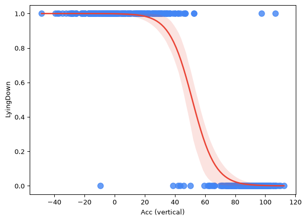

```python
sns.regplot(
    x="Acc (vertical)"
    , y="LyingDown"
    , data=activity
    , logistic=True
    , scatter_kws={"s": 70, "color": "#4285f4"}
    , line_kws={"color": "#ea4335", "linewidth": 2})
```

The plot displays a sharp S-shaped curve. The shaded region around the line indicates the confidence band.

You can observe two horizontal lines of data points. One where the person is lying down, when the variable equals one. The other one is when the person is not lying down, when the variable equals zero. We’ll discuss how to interpret logistic regression results next.

In this video, you told the computer to find the best way to determine the likelihood of someone lying down based on vertical acceleration. You also began the work of interpreting the results and were able to plot the model. Coming up, we’ll consider a variety of ways to evaluate the quality of the model and how to tell a meaningful story about the data.

You have built your first binomial logistic regression. You were able to calculate the parameter estimates and graph the logistic regression. In this video, we’ll use the metrics and graphs produced in Python to evaluate how good your model actually was.

To recap, you’re working with the activity data that measured acceleration and whether or not a person was lying down. You previously saved the data into training and hold out datasets and the logistic regression model as a variable `clf`. Now input the holdout data into the `predict` method to get the predicted labels from the model. Save these predictions as a variable called `y_pred`. Note that Maximum likelihood estimation(MLE) predicts a probability that an observation is a zero or one.

```python
y_pred = clf.predict(X_test)
print('Predictions: ', y_pred)
```

```
Predictions:  [0 1 0 0 1 0 0 1 1 0 1 0 0 1 1 0 0 0 1 1 0 1 1 0 1 0 1 1 0 1 0 0 1 0 1 0 1
 1 1 1 0 1 0 1 0 0 0 0 0 0 1 0 0 1 0 1 0 1 0 1 0 0 0 1 0 0 1 1 0 0 1 0 0 0
 0 0 1 1 0 0 0 1 1 0 1 0 1 1 1 0 1 0 1 1 1 1 1 0 1 1 0 0 1 1 1 1 1 1 1 0 0
 0 1 0 1 1 0 1 1 1 1 1 1 0 1 1 0 1 1 0 1 0 0 1 0 0 1 1 0 1 0 1 0 0 1 0 1 1
 1]
```

The `predict` function from scikit-learn actually labels each observation with a zero or one. The `predict` function works by assuming a threshold of 0.5.

- So if MLE predicts a value greater than or equal to 0.5, the `predict` function will label that observation a one.
- If MLE predicts a value less than 0.5, the ‘predict’ function will label that observation a zero.

The `predict_proba` function, on the other hand, will allow you to check what probability was predicted for each data point.

```python
y_prob = clf.predict_proba(X_test)
print('Probabilities: ', y_prob[:10])  # Displaying the first 10 probabilities for brevity
```

```
Probabilities:  [[9.76830914e-01 2.31690858e-02]
 [2.48835691e-03 9.97511643e-01]
 [9.89571940e-01 1.04280601e-02]
 [9.98943302e-01 1.05669826e-03]
 [2.18734630e-04 9.99781265e-01]
 [9.89571940e-01 1.04280601e-02]
 [9.95339911e-01 4.66008916e-03]
 [4.26601781e-03 9.95733982e-01]
 [2.76555093e-02 9.72344491e-01]
 [9.76830914e-01 2.31690858e-02]]
```

Now that you have predictions about whether each observation is a zero or one, you can create a confusion matrix that will give you a quick overview of how well your model categorized each data point in the holdout dataset.

A confusion matrix is a graphical representation of how accurate a classifier is at predicting the labels for a categorical variable.

First let’s take a look at the values of the true labels and the predicted labels

```python
print("true labels ", y_test.value_counts())
# Predicted labels (NumPy array converted to Series)
print("\nPredicted labels:\n", pd.Series(y_pred).value_counts())
```

```
true labels  LyingDown
1    77
0    72
Name: count, dtype: int64

Predicted labels:
 1    78
0    71
Name: count, dtype: int64
```

We can visualize the matrix of both:

```python
# Cross-tabulate true vs predicted labels directly
crosstab = pd.crosstab(y_test, y_pred, rownames=['Actual'], colnames=['Predicted'])
print(crosstab)
```

```
Predicted   0   1
Actual
0          70   2
1           1  76
```

Or use a graph with `sklearn.metrics`

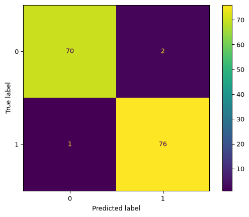

```python
import sklearn.metrics as metrics


cm = metrics.confusion_matrix(y_test, y_pred, labels =clf.classes_)
disp = metrics.ConfusionMatrixDisplay(confusion_matrix=cm, display_labels=clf.classes_)
disp.plot()
```

The diagonal from upper left to lower right (The intersection between true label 0 and predicted label 0, as well as the intersection between true label 1 and predicted label 1) displays how many data points were accurately categorized by a classifier for each category. The other squares in the grid convey how many data points were misclassified.

On the axes of the confusion matrix there are labels indicating the category of data point as zero or 1. Zero means the person was labeled as not lying down for that observation. One means a person was labeled as lying down for that observation. ****

**Data professionals call a data point that is labeled zero a negative data point**.

**A data point that is labeled one is a positive data point.**

In the upper left corner of the confusion matrix we have the count of observations that our classifier predicted as not lying down and they actually were not lying down. These are called **true negatives**. Moving to the lower right, we have our **true positives**. This is our count of observations that our classifier predicted as lying down and they actually were lying down. Now let’s consider where our model’s predictions were wrong. In the upper right is the count of observations where a classifier predicted the person was lying down, but they were NOT lying down. These are **false positives**. In the lower left is the count of observations where our classifier predicted the person was not lying down, but they WERE lying down. These are **false negatives**.

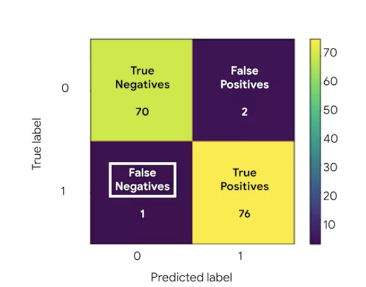

In a great model we should observe a high proportion of true positives and true negatives and a low proportion of false positives and false negatives. In this video, you learned about the confusion matrix. This versatile tool can help you add depth to stories you tell about logistic regression models. In the following videos, we’ll discuss even more ways to evaluate the quality of a logistic regression model. I’ll meet you there!

# 3 Assessing the model

Earlier we covered confusion matrices which helped to visually represent and quantify how well a logistic regression performed. In this video we’ll continue to work through the analyze and construct phase of pace and discuss evaluation metrics for logistic regression. These metrics summarize the true positives, true negatives, false positives, and false negatives presented by the confusion matrix. The three metrics we’ll discuss are precision, recall, and accuracy. You can access the functions used in this video through `scikit-learn metrics` module, and we’ll continue to consider our activity data example.

## 3.1 Precision

Precision measures the proportion of positive predictions that were true positives.

$$\text{Precision}=\frac{\text{True Positives}}{\text{True Positives + False Positives}}$$

**Answers the question**: *Out of everything the model claimed was positive, how much was actually positive?*

In this case precision would tell us among the people we predicted to be lying down, how many of them are actually lying down? Scikit learns metrics library has a convenient function that does the math for us. We input the $y$ values in our holdout data set and the $y$ values that our model predicted from the $x$-values in our holdout data set.

$$\text{Precision}=\frac{\text{True Positives}}{\text{True Positives + False Positives}} = \frac{76}{76+2}=0,974$$

We can say that from all the labels that the model predicted as 1s, 97.4% were correct

```python
import sklearn.metrics as metrics
metrics.precision_score(y_test,y_pred)
```

```
0.9743589743589743
```

Since the range of precision is 0-1, a score of 0.97 is great.

## 3.2 Recall

Recall measures the proportion of positives that the model was able to identify correctly.

$$Recall= \frac{\text{True Positives}}{\text{True Positives + False Negatives}}$$

**Answers the question:** *Out of all the actual positive cases that existed in real life, how many did the model manage to catch?*

Remember that false negatives are those that we’re lying down, but the model did not detect as lying down. Recall measures the proportion of people the model correctly identified as laying down out of the people who are actually lying down.

$$Recall= \frac{\text{True Positives}}{\text{True Positives + False Negatives}} = \frac{76}{76+1}=0,987$$

We input the same data that we input to get precision, but using the recall score function from `scikit-learn`.

```python
metrics.recall_score(y_test,y_pred)
```

```
0.987012987012987
```

We get a recall of about 0.98, and since recall also ranges 0-1 this model performs pretty well.

## 3.3 Accuracy

Lastly, we have accuracy.

Accuracy is the proportion of data points that were correctly categorized.

$$Accuracy = \frac{\text{True Positives + True Negatives}}{\text{Total predictions}}$$

**Answers the question:** *Out of all total predictions the model made (both positive and negative), what percentage were completely right?*

In our activity example accuracy will measure the proportion of people our model correctly identified as laying down, and the proportion of people are model correctly identified as not laying down.

We can use the accuracy score function from scikit-learn.

```python
metrics.accuracy_score(y_test, y_pred)
```

```
0.9798657718120806
```

In this case our model achieved an accuracy score of 0.97, but note that most of the time precision recall and accuracy are not all this high.

This is to be expected, two other common evaluation techniques that may be helpful when working with classifiers are the **ROC curve and AUC.** These concepts are related to thresholds, true positives, and false positives.

Although we use a threshold of 0.5 to generate our predictions, sometimes the threshold is determined based on the scenario.

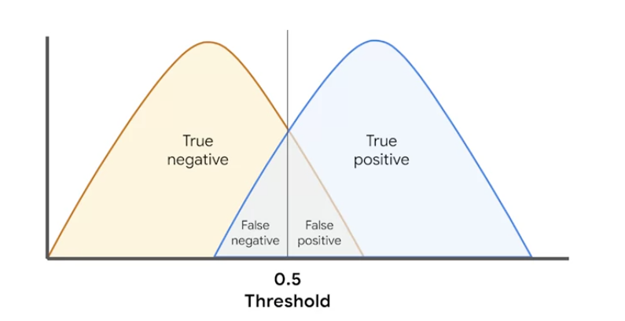

Notice that when we decrease the threshold the true positive increases because we are predicting more observations to be positive, but the false positive rate also increases.

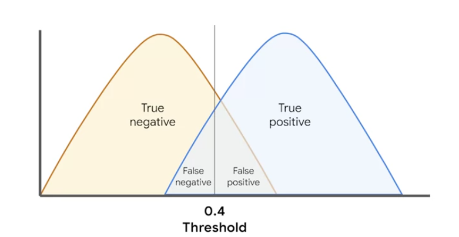

The model’s true positive rate and false positive rate changes at every threshold. With an ideal model there would exist a threshold where the true positive rate is high and the false positive rate is low.

We can use an ROC curve in AUC to examine how the true positive and false positive rate change together at every threshold.

Data professionals may use ROC curves and AUC when comparing classification models, so we’ll explore them later in this program.

In this video, we covered a number of important metrics. These concepts are similar and related. Don’t expect to grasp all the nuances of the content on your first pass. Allow yourself some extra time and practice to understand how best to apply these measurement tools to support the stories you’re telling with data. Now we’ll start constructing the kinds of stories you can share with logistic regression.

**Metric selection depends entirely on the cost of making a mistake in a specific real-world context.**

High accuracy can be a dangerous illusion, especially with **imbalanced datasets** (like a rare disease, where real positive cases are $1\%$).

### 3.3.1 When Recall is Most Important

> **Goal:** Catch every positive case. False alarms are acceptable; missed positives are catastrophic.
- **The Cost Function:** High cost for **False Negatives** (saying “Negative” when the answer is actually “Positive”).
- **The Strategy:** Set a sensitive threshold to cast a wide net. You prefer to double-check a false alarm rather than let a true case slip through.

**Real-World Contexts:**

- **Medical Screening (Rare Disease):** As you noted, missing a sick patient (False Negative) means they don’t get treatment, which can be fatal. A false alarm (False Positive) just means running a second test to confirm.
- **Fraud Detection:** It is better to temporarily flag a legitimate credit card transaction as suspicious (False Positive) and send a text verification than to miss an actual fraudulent transaction (False Negative).
- **Defect Detection in Manufacturing (Safety Equipment):** Missing a faulty car airbag (False Negative) leads to injury or death. Throwing away a good airbag by mistake (False Positive) just costs a few dollars.

### 3.3.2 When Precision is Most Important

> **Goal:** Be absolutely certain when you flag something. Missed positives are acceptable; false alarms destroy trust or waste expensive resources.
- **The Cost Function:** High cost for **False Positives** (saying “Positive” when the answer is actually “Negative”).
- **The Strategy:** Be conservative. Only predict positive when confidence is extremely high.

**Real-World Contexts:**

- **Spam Detection:** If a good email goes to the Spam folder (False Positive), you might miss a job offer or a key work message. If a spam email gets into your inbox (False Negative), it’s just a mild annoyance. Here, **Precision matters more**—when the filter claims an email is spam, it better be right.
- **Legal / Judicial Systems:** The baseline principle “innocent until proven guilty” prioritizes high Precision. Convicting an innocent person (False Positive) is considered far worse than failing to convict a guilty person (False Negative).
- **High-Cost Interventions (Targeted Marketing/Sales):** If sending a sales rep to visit a high-value client in person costs $5,000, you only want to target leads predicted as “high probability” with extremely high precision. False positives waste real budget.

### 3.3.3 When Accuracy is Most Important

> **Goal:** Get an overall snapshot of correct predictions across all classes equally.
- **The Cost Function:** Both False Positives and False Negatives carry roughly equal, low-to-moderate costs.
- **The Prerequisite:** **Balanced Datasets** (e.g., 50% class A, 50% class B).

**Real-World Contexts:**

- **Digit Recognition (OCR):** Scanning handwritten zip codes on mail. Misclassifying an 8 as a 3 costs about the same as misclassifying a 3 as an 8.
- **Sentiment Analysis for General Feedback:** Classifying customer reviews as simply “Positive” or “Negative” when you have a roughly equal mix of both, and no single misclassification causes a critical failure.

### 3.3.4 How to Balance Them: F1-Score & Custom Costs

When you need a single metric that balances Precision and Recall, standard practice uses the **F1-Score**:

$$\text{F1-Score} = 2 \times \frac{\text{Precision} \times \text{Recall}}{\text{Precision} + \text{Recall}}$$

The F1-Score uses the **harmonic mean**, which heavily punishes extreme trade-offs. If your model gets 99% Precision but 1% Recall, standard averaging gives 50%, but the F1-Score collapses to **1.98%**, signaling that the model is failing on one front.

Example:

We will simulate a rare disease scenario where **99% of patients are healthy (Negative)** and only **1% have the disease (Positive)**.

Step 1: Generate an Imbalanced Synthetic Dataset.

We create 1,000 patient records. 990 patients are healthy (`0`) and 10 patients have the rare disease (`1`).

```python
import numpy as np
import pandas as pd

# Set random seed for reproducibility
np.random.seed(42)

# Generate 1,000 samples: 990 Healthy (0), 10 Rare Disease (1)
y_true = np.array([0] * 990 + [1] * 10)

# Shuffle the labels so they aren't in order
np.random.shuffle(y_true)

# Check the distribution
print(pd.Series(y_true).value_counts())
```

```
0    990
1     10
Name: count, dtype: int64
```

Step 2: Imagine a model that predicts Healthy (0) for 995 patients and only flags 5 patients as having the disease (1). Out of those 5 positive predictions:

- It gets **2 right** (True Positives).
- It gets **3 wrong** (False Positives — healthy people given a false alarm).
- It misses **8 actual sick people** (False Negatives — saying they are healthy when they are sick).

```python
# Simulate our model's predictions
# Suppose the model predicts 0 for almost everyone, but flags 5 people as positive
y_pred = np.zeros(1000, dtype=int)

# Identify indices of actual sick patients
sick_indices = np.where(y_true == 1)[0]
healthy_indices = np.where(y_true == 0)[0]

# Model correctly catches 2 sick people (True Positives)
y_pred[sick_indices[:2]] = 1

# Model incorrectly flags 3 healthy people as sick (False Positives)
y_pred[healthy_indices[:3]] = 1
```

Step 3: Compute the Confusion Matrix Breakdown

Let’s extract the raw counts: True Negatives (TN), False Positives (FP), False Negatives (FN), and True Positives (TP).

```python
from sklearn.metrics import confusion_matrix

tn, fp, fn, tp = confusion_matrix(y_true, y_pred).ravel()

print(f"True Negatives (Healthy correctly identified):  {tn}")
print(f"False Positives (False Alarms):                {fp}")
print(f"False Negatives (MISSED Sick Patients):        {fn}")
print(f"True Positives (Sick Patients caught):         {tp}")
```

```
True Negatives (Healthy correctly identified):  987
False Positives (False Alarms):                3
False Negatives (MISSED Sick Patients):        8
True Positives (Sick Patients caught):         2
```

Step 4: Calculate and Compare All Metrics

Now we pass y_true and y_pred into scikit-learn’s metrics module and calculate Accuracy, Precision, Recall, and F1-Score manually and via functions.

```python
from sklearn.metrics import accuracy_score, precision_score, recall_score, f1_score

acc = accuracy_score(y_true, y_pred)
prec = precision_score(y_true, y_pred)
rec = recall_score(y_true, y_pred)
f1 = f1_score(y_true, y_pred)

print(f"Accuracy:  {acc:.4f}  ({acc*100:.1f}%)")
print(f"Precision: {prec:.4f}  ({prec*100:.1f}%)")
print(f"Recall:    {rec:.4f}  ({rec*100:.1f}%)")
print(f"F1-Score:  {f1:.4f}  ({f1*100:.1f}%)")
```

```
Accuracy:  0.9890  (98.9%)
Precision: 0.4000  (40.0%)
Recall:    0.2000  (20.0%)
F1-Score:  0.2667  (26.7%)
```

Step 5: Metric-by-Metric Analysis

Here is what each number actually means in this scenario:  
1. Accuracy (98.9%) — The Dangerous Illusion

Math: $\frac{\text{TN} + \text{TP}}{\text{Total}} = \frac{987 + 2}{1000} = \frac{989}{1000} = 98.9\%$

Why it deceives us: The model looks nearly perfect because it got 987 True Negatives right simply by guessing “Healthy” all the time. But in a medical setting, this model is a failure because it lets 8 out of 10 sick people leave the hospital untreated.

2. Recall (20.0%) — The True Reality Check

Math: $\frac{\text{TP}}{\text{TP} + \text{FN}} = \frac{2}{2 + 8} = \frac{2}{10} = 20.0\%$

What it tells us: Out of the 10 actual sick patients in real life, the model only caught 2 of them. It missed 80% of the disease cases. For a rare disease model, Recall is your primary KPI, and 20% indicates total failure.

3. Precision (40.0%) — Quality of Positive Flags

Math: $\frac{\text{TP}}{\text{TP} + \text{FP}} = \frac{2}{2 + 3} = \frac{2}{5} = 40.0\%$

What it tells us: When the model raised an alarm and predicted “Disease”, it was only correct 40% of the time (2 out of 5 times). The other 3 predictions were false alarms.

4. F1-Score (26.7%) — The Balanced Indicator

Math: $2 \times \frac{\text{Precision} \times \text{Recall}}{\text{Precision} + \text{Recall}} = 2 \times \frac{0.40 \times 0.20}{0.40 + 0.20} = \frac{0.16}{0.60} = 26.7\%$

Why it helps: Notice how F1-Score ignores the massive 987 True Negatives. Because it takes the harmonic mean of Precision (40%) and Recall (20%), it collapses to 26.7%, accurately signaling that the model performs poorly overall on positive detections.

# 4 Common logistic regression metrics in Python

Logistic regression is a powerful technique for categorical prediction tasks in data science. Data professionals often use metrics such as precision, recall, and accuracy, as well as visualizations such as ROC curves, to gauge the performance of their logistic regression models. It is important to evaluate the performance of a model, as this shows how well the model can make predictions. The results from applying metrics can be used to report how well a model performs to relevant stakeholders.

In this reading, you will review parts of a confusion matrix and understand how to compute and visualize metrics for evaluating logistic regression through code in Python.

## 4.1 Parts of a confusion matrix

A confusion matrix helps summarize the performance of a classifier. The components of a confusion matrix are used to compute metrics for evaluating logistic regression classifiers.

[figure not shown]

The four key parts of a confusion matrix, in the context of binary classification, are the following:

1. **True negatives:** The count of observations that a classifier correctly predicted as False (0)

2. **True positives:** The count of observations that a classifier correctly predicted as True (1)

3. **False positives:** The count of observations that a classifier incorrectly predicted as True (1)

4. **False negatives:** The count of observations that a classifier incorrectly predicted as False (0)

These counts are useful in computing metrics such as precision, recall, accuracy, and ROC for evaluating logistic regression classifiers.

## 4.2 Precision

One of the major metrics for evaluating a logistic regression classifier is **precision**. Precision measures the proportion of data points predicted as True that are actually True.

Imagine that you have built a logistic regression classifier for email spam detection, trained this classifier on a relevant dataset, and used this classifier to generate predictions for a set of emails. The predictions consist of True and False values. True represents an email predicted as spam, and False represents an email predicted as not spam. The precision for this classifier would convey the proportion of emails that are actually spam, out of all the emails that have been predicted as spam.

The formula for precision is as follows:
$$\text{Precision}=\frac{\text{True Positives}}{\text{True Positives + False Positives}}$$

To compute precision in Python, you can use the ‘precision_score()’ function from the **metrics** module in the **sklearn** library. You can start with the following import statement.

`import sklearn.metrics as metrics`

The `precision_score()` function takes in true values and predicted values as arguments and returns the precision score. Assume that **`y_test`** and **`y_pred`** are variables that contain true values and predicted values respectively. You can use the following code to compute the precision.

`metrics.precision_score(y_test,y_pred)`

In the context of email spam detection, if precision_score() returns 0.91, that means 91% of the emails predicted as spam are indeed spam.

## 4.3 Recall

Another major metric for evaluating a logistic regression classifier is **recall**. Recall measures the proportion of data points that are predicted as True, out of all the data points that are actually True. Imagine that you have built a logistic regression classifier for fraud detection and generated predictions. In the predictions, True represents a credit card transaction predicted as fraudulent, and False represents a credit card transaction predicted as not fraudulent. The recall for this classifier would convey the proportion of fraudulent credit card transactions that the classifier correctly identified as such.

The formula for recall is as follows:

$$Recall= \frac{\text{True Positives}}{\text{True Positives + False Negatives}} = \frac{76}{76+1}=0,987$$

To compute recall in Python, you can use the ’recall_score() function from the metrics module. The function takes in true values and predicted values as arguments and returns the recall score. You can use the following code to compute the recall.

`metrics.recall_score(y_test,y_pred)`

In the context of fraud detection among credit card transactions, if the **recall_score()** function returns 0.87, that means 87% of the fraudulent credit card transactions are correctly detected as fraudulent.